# 170721_coursera_developing data product(week4)

Taesoon Kim

Jul-21-2017

# Introduction and Assignment

- This assignment is course project in Coursera lecture, Developing data product.
  - I will solve 2 questions
- Question 1.
  - I have to use shiny() function, and share my server.R and ui.R
  - In my code, I receive various input values, and output is mpg text
- Question 2.
  - I will make rmarkdown and use slidify() function
  - And share 5 page presentation in my github and Rpubs

# Slide with R Output

```r
# Set the directory
setwd("D:/1-1. R studio/Lecture9. Developing data product/week4/170724_coursera_ddp")

# Load dataset
data(mtcars)

#check the "mtcars" data
str(mtcars)
```

```
## 'data.frame':    32 obs. of  11 variables:
##  $ mpg : num  21 21 22.8 21.4 18.7 18.1 14.3 24.4 22.8 19.2 ...
##  $ cyl : num  6 6 4 6 8 6 8 4 4 6 ...
##  $ disp: num  160 160 108 258 360 ...
##  $ hp  : num  110 110 93 110 175 105 245 62 95 123 ...
##  $ drat: num  3.9 3.9 3.85 3.08 3.15 2.76 3.21 3.69 3.92 3.92 ...
##  $ wt  : num  2.62 2.88 2.32 3.21 3.44 ...
##  $ qsec: num  16.5 17 18.6 19.4 17 ...
##  $ vs  : num  0 0 1 1 0 1 0 1 1 1 ...
##  $ am  : num  1 1 1 0 0 0 0 0 0 0 ...
##  $ gear: num  4 4 4 3 3 3 3 4 4 4 ...
##  $ carb: num  4 4 1 1 2 1 4 2 2 4 ...
```

```r
# Focus on MPG and draw a histogram
summary(mtcars$mpg)  # mpg consists of numbers, I can check
```

```
##    Min. 1st Qu.  Median    Mean 3rd Qu.    Max.
##   10.40   15.42   19.20   20.09   22.80   33.90
```

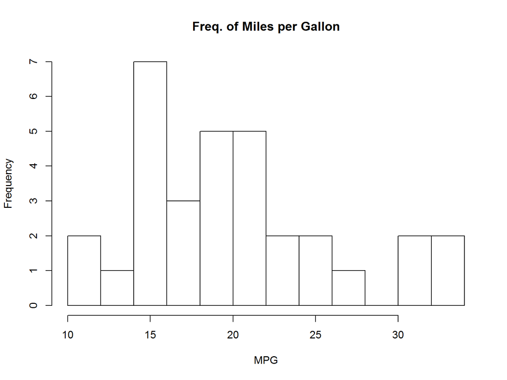

```r
# Draw a histogram with respect to MPG

hist(mtcars$mpg,breaks=10,main="Freq. of Miles per Gallon",xlab="MPG")
```

# Cross validation

```r
# Separate the training data and testing data
set.seed(135)
library(ggplot2)
library(lattice)
library(caret)     # In order to use createDataPartition() function
inTrain<-createDataPartition(mtcars$mpg,p=0.6,list=FALSE)
training<-mtcars[inTrain,]
testing<-mtcars[-inTrain,]
dim(training)
```

```
## [1] 21 11
```

```r
dim(testing)
```

```
## [1] 11 11
```

I use createDataPartition() function, and separate training data(60%) and testing data(40%). I am going to adjust various modeling methods using training data, since then check the results correct or not using testing data.

# Random forest

```r
# randomForest() function
library(randomForest)
rf_training<-randomForest(mpg~.,data=training,importance=TRUE)
rf_training
```

```
##
## Call:
##  randomForest(formula = mpg ~ ., data = training, importance = TRUE)
##                Type of random forest: regression
##                      Number of trees: 500
## No. of variables tried at each split: 3
##
##           Mean of squared residuals: 9.129866
##                     % Var explained: 76.48
```

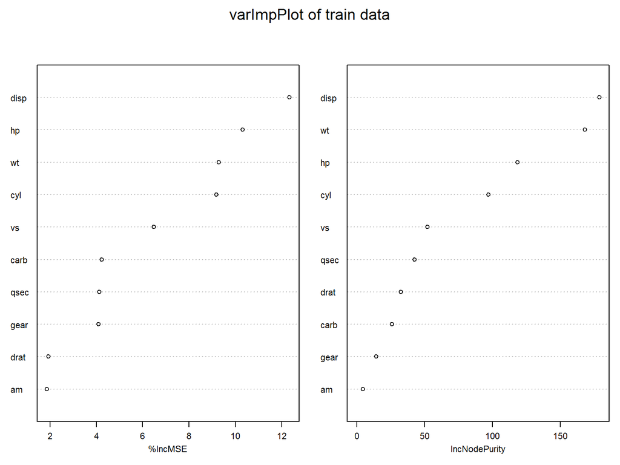

```r
# draw a graph
varImpPlot(rf_training,main="varImpPlot of train data",cex=0.7)
```

Using random forest method, I will check which variable is the most effective in this data set. In this data set, disp is the most effective and wt, hp, cyl are also effective.